# Data Science - JHU - Capstone - Milestone

Oscar Forero

16 November 2014

First I downloaded and sampled the files at 30% to do some exploratory analysis. One of the first things I noticed was that the file contained NULL and it was in windows format which was creating problems for me. For this reason the first step I took was to translate the files to *unix* format using the following command:

```bash
tr -cd '\11\12\40-\176' < en_US/en_US.news.txt | dos2unix > en_US_fix/en_US.news.txt
tr -cd '\11\12\40-\176' < en_US/en_US.blogs.txt | dos2unix > en_US_fix/en_US.blogs.txt
tr -cd '\11\12\40-\176' < en_US/en_US.twitter.txt | dos2unix > en_US_fix/en_US.twitter.txt
```

In order to sample I first obtained the total number of lines with a library function. Then generated a sample of 30% of numbers between 1 and the size of each file without replacement.

To obtain the actual lines I used the *sed* command from *unix*. I created a temporary file with the selection commands to be used with *sed*, then execute a system2 call.

This was a pretty expensive step, I saved the samples into a new directory from which I could just read the smaller files as necessary.

The project mentioned the need to deal with profanity, suggesting removing the offensive words from the input. I don’t think this is a good idea without at least a strong definition of what should be considered offensive.

For example a [list](http://www.cs.cmu.edu/~biglou/resources/bad-words.txt) provided by [professor Luis von Ahn from Carnegie Mellon](http://www.cs.cmu.edu/~biglou/resources/) includes 1383 words which include words like adult and africa, this is clearly excessive.

To get a feel for how much of a problem is profanity really I decided to use the famous [7 dirty words](http://en.wikipedia.org/wiki/Seven_dirty_words) as a proxy to estimate the porcentage of documents containing *offensive* words.

From the point of view of a product for users like autocomplete it may be valuable to not automatically generate highly embarrassing words like the seven in the above list.

Then I performed some basic summary counting the words, lines, and lines with profanity in the original files and in the sample.

[output not shown]

Plotting the proportion of lines with at least one of the *7 dirty words* give us a sense that there isn’t much of a profanity problem.

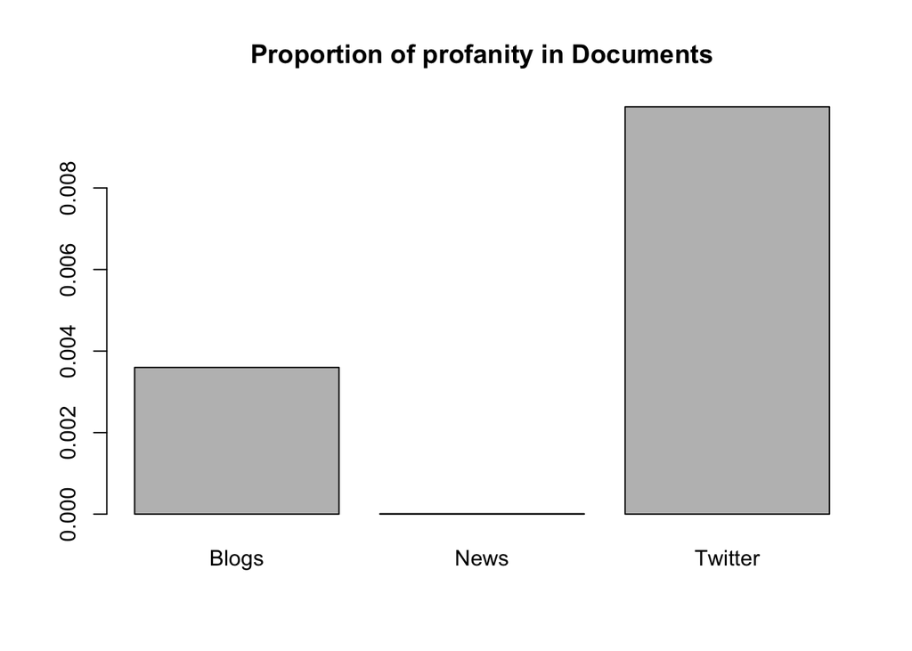

And plotting the proportion of unique words in the sample versus unique words in the complete file show us that the quality of sample was high.

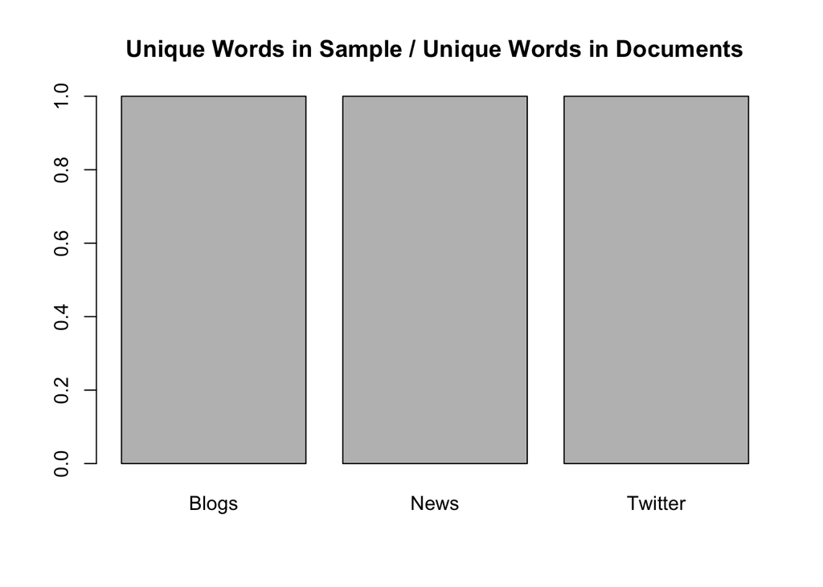

## 500 most common words in Blog comments

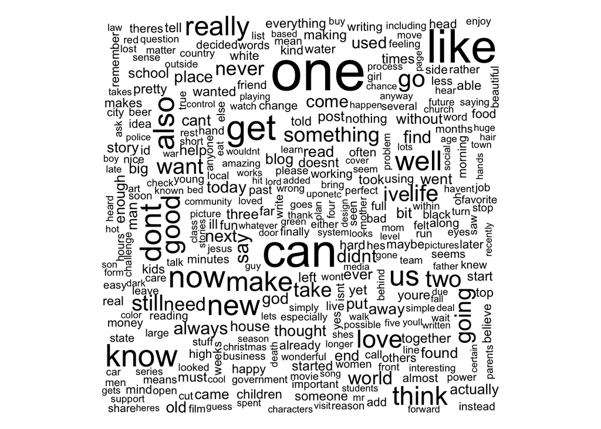

## 500 most common words in News comments

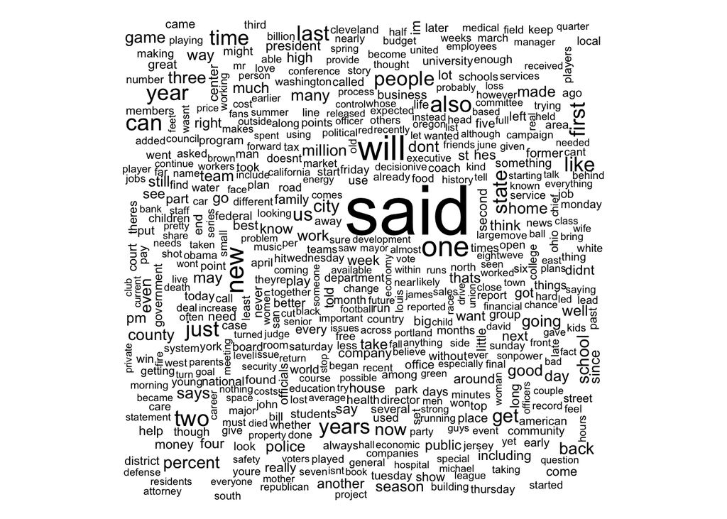

## 500 most common words in Twitter

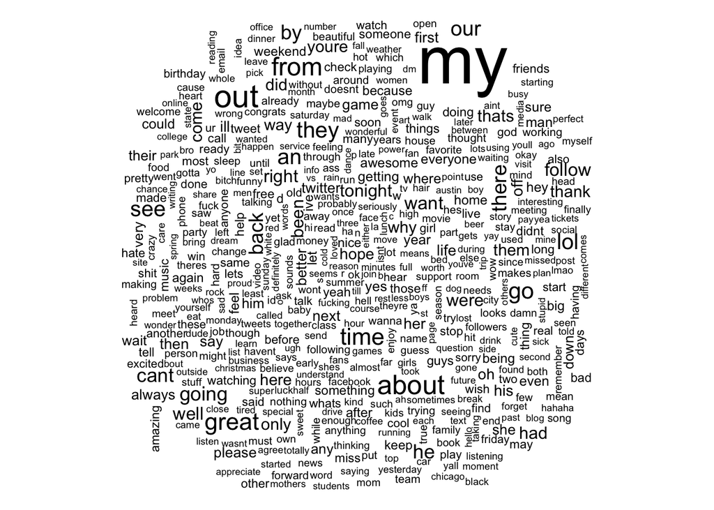